# Lab4_25_26_Hugo_Garcia_Souto

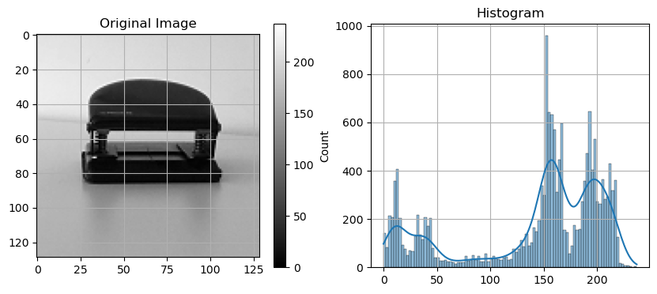

```
--- K-Means Segmentation ---
```

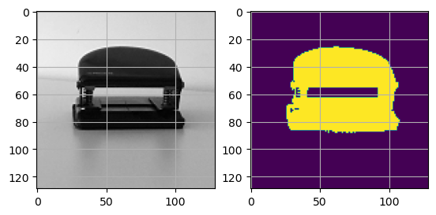

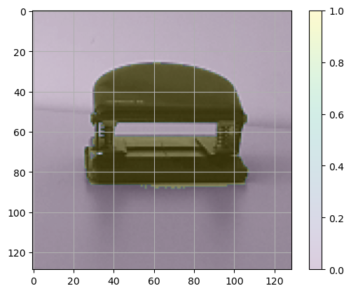

```python
#Apply K-means (calling RunKMeans) to segment the object from the background, try with k=2

plt.figure(figsize=(10, 4))
plt.subplot(1, 2, 1)
plt.imshow(img, cmap='gray')
plt.title("Original Image")
plt.colorbar()

plt.subplot(1, 2, 2)
sns.histplot(img.reshape(-1), bins=100, kde=True)
plt.title("Histogram")
plt.show()

print("--- K-Means Segmentation ---")
# Apply K-means to segment the object from the background (2 clusters)
RunKMeans(img, 2)
```

Meanshift with default bandwidth (this might take some time, be patient).

```
Found 2 clusters
```

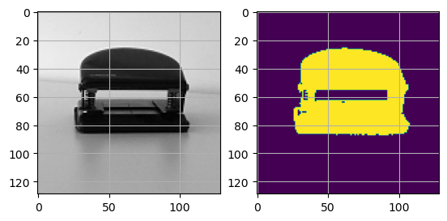

```python
ms_default = MeanShift().fit(img.reshape(-1, 1))

print('Found', len(np.unique(ms_default.labels_)), 'clusters')
fig, ax = plt.subplots(1, 2)
ax[0].imshow(img, cmap='gray')
ax[1].imshow(ms_default.labels_.reshape(img.shape))
plt.show()
```

Meanshift with different bandwidths. We first define a convenience function to run experiments more easily.

```python
def RunMeanShift(img, bw):
  ms = MeanShift(bandwidth=bw).fit(img.reshape(-1, 1))
  print('Found', len(np.unique(ms.labels_)), 'clusters')
  fig, ax = plt.subplots(1, 2)
  ax[0].imshow(img, 'gray')
  ax[1].imshow(ms.labels_.reshape(img.shape))
  plt.show()
```

```
--- MeanShift Experiments (Varying Bandwidth) ---
Found 23 clusters
```

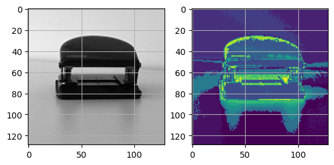

```
Found 5 clusters
```

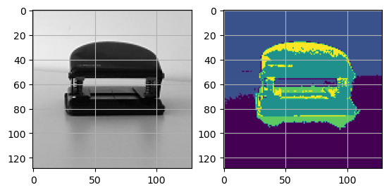

```python
# Using the RunMeanShift function defined above, run MeanShift with at least two different bandwidth values (e.g. 5, 10, 20)

# ---------------------------------------------------------
# MeanShift with Different Bandwidths
# ---------------------------------------------------------

print("--- MeanShift Experiments (Varying Bandwidth) ---")
# Run MeanShift with at least two different bandwidth values
# Small bandwidth (e.g., 5)
RunMeanShift(img, 5)

# Medium/Large bandwidth
RunMeanShift(img, 20)
```

**Exercise 8 (0.25 pts):** Now we work with an example that uncovers some of the short-commings of the methods seen so far. Our goal is to separate the foreground of a not so well taken photograph of a sudoku game. Naturally, we consider as foreground the numbers and the gridlines.

```python
img = cv2.imread(images_path + 'sudoku.jpg', cv2.IMREAD_GRAYSCALE)
if img is None:
  sys.exit('Input image not found, check the path')
```

[figure not shown]

```python
plt.imshow(img, cmap='gray')
plt.colorbar()
plt.show()
```

We calculate the histogram and visualize it using matplotlib and pyplot.

[figure not shown]

```python
if img is None:
    print("Error: 'sudoku.jpg' not found.")
else:
    # Visualization & Histogram
    plt.figure(figsize=(10, 4))
    plt.subplot(1, 2, 1)
    plt.imshow(img, cmap='gray')
    plt.title('Original Image')
    plt.axis('off')

    # Calculate histogram with matplotlib
    plt.subplot(1, 2, 2)
    plt.hist(img.ravel(), bins=256, range=[0, 256], color='gray', alpha=0.7)
    plt.title('Histogram (Matplotlib)')
    plt.show()
```

We do the same using the “seaborn” package.

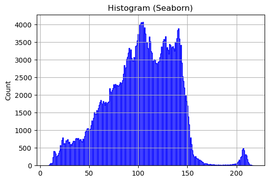

```python
if img is not None:
    plt.figure(figsize=(6, 4))
    sns.histplot(img.ravel(), bins=256, color='blue', element='step')
    plt.title('Histogram (Seaborn)')
    plt.show()
```

We compute a smoothed version of the histogram using KDE from the “seaborn” package.

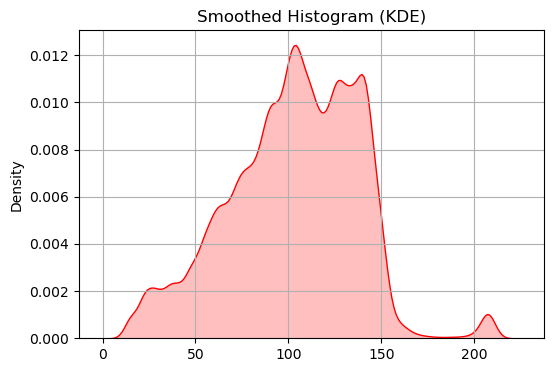

```python
if img is not None:
    plt.figure(figsize=(6, 4))
    sns.kdeplot(img.ravel(), fill=True, color='red')
    plt.title('Smoothed Histogram (KDE)')
    plt.show()
```

Apply global thresholding to 'sudoku.jpg'. Can you find a number of levels to separate the foreground (i.e. the numbers and the gridlines)?

[figure not shown]

```python
#Try to separate the foreground (digits and grid lines) from the background. You can refresh your memory by looking at exercise 2

if img is not None:
    # Due to uneven lighting, it's impossible to find one perfect value.
    # Let's try an intermediate value, e.g., 80.
    manual_thr = 80
    _, manual_seg = cv2.threshold(img, manual_thr, 255, cv2.THRESH_BINARY_INV)

    plt.figure(figsize=(5, 5))
    plt.imshow(manual_seg, cmap='gray')
    plt.title(f'Global Manual Threshold (T={manual_thr})')
    plt.axis('off')
    plt.show()
```

Let's try Otsu's thresholding.

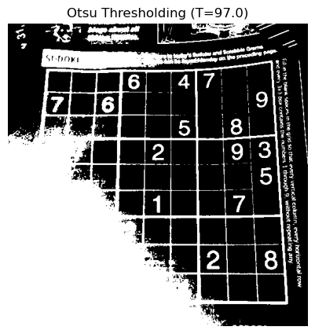

```python
#Apply Otsu's method (revisit exercise 3 and 4)

if img is not None:
    otsu_thr, otsu_seg = cv2.threshold(img, 0, 255, cv2.THRESH_BINARY_INV + cv2.THRESH_OTSU)

    plt.figure(figsize=(5, 5))
    plt.imshow(otsu_seg, cmap='gray')
    plt.title(f'Otsu Thresholding (T={otsu_thr:.1f})')
    plt.axis('off')
    plt.show()
```

How do you rate the performance of Otsu's thresholding?